# Food Access & Nutrition Equity in Texas

SQL - Project Workflow and Report (Pairs)

Authors

Chi-Tse Chiang(cc79734)

Cian-Rong Chen(cc79648)

Published

December 5, 2025

# 1 Summary

This project aims to develop a data wrangling pipeline that integrates three datasets related to **food access**, **nutritional quality**, and **socioeconomic disparities** in Texas. Using data from the *USDA Food Access Research Atlas*, *CORGIS County Demographics dataset*, and *CORGIS Food Nutrition* dataset. The pipeline is implemented across four technical environments:

- Python with Pandas
- R with tidyverse
- SQL
- Excel

The resulting clean dataset enables exploration of how food accessibility in Texas intersects with nutritional availability and demographic factors such as poverty or race/ethnicity. This work emphasizes the technical process of data wrangling and reproducible pipeline development, providing a foundation for future research into food security and health equity disparities across Texas communities.

# 2 Data Sources

## 2.1 USDA Food Access Research Atlas

**Source**: [USDA Data Products](https://www.ers.usda.gov/data-products/food-access-research-atlas)

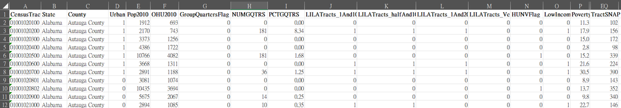

Provides census-tract-level indicators of supermarket accessibility and food access challenges for different demographic groups. Includes population, housing, income, race, SNAP benefits, and geographic accessibility measures (e.g., low-income populations living >1 mile from a grocery store).

**Wrangling Issues**:

- Very wide (147 columns) and long (72,000+ rows) dataset requiring subsetting to 10–15 meaningful columns
- Needs standardization of county and state names for **merging**.
- Requires treatment of missing or 0 placeholder values
- Census tract-level data must be aggregated to county level to match other datasets

## 2.2 U.S. County Demographics(From 2010s)

**Source**: [CORGIS Dataset Project, County Demographics](https://corgis-edu.github.io/corgis/csv/county_demographics/)

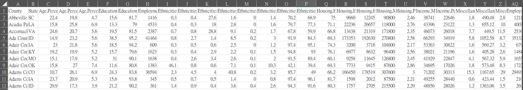

[3140rows x 43 columns]

County-level data from 2010–2019 across the U.S., including age distribution, education, employment, ethnicity, household income, housing characteristics, and health-related statistics like travel time and veteran status.

**Wrangling Issues**:

- **Filtering** to only Texas counties from national dataset.
- **Missing values** encoded as -1 need identification and handling.
- Long dot-separated column names (e.g., Ethnicities.White Alone) require **renaming** and flattening for usability.
- County and state name standardization needed to **match** with USDA Food Access Atlas

## 2.3 USDA Food Composition

**Source**: [CORGIS Dataset Project, Food](https://corgis-edu.github.io/corgis/csv/food/)

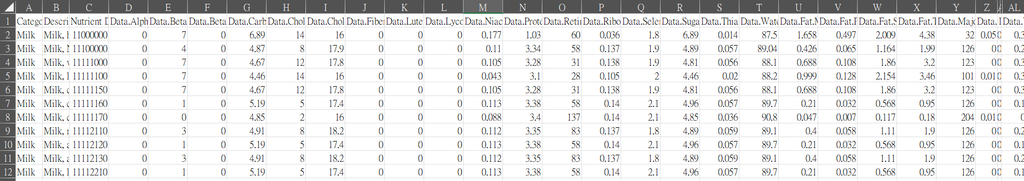

[7084rows x 38columns]

Contains nutritional breakdowns of thousands of foods, with fields for macronutrients (protein, fat, carbohydrates), vitamins (A, C, B12, etc.), and minerals (calcium, iron, magnesium). Each row represents a distinct food item.

# 3 Selected Columns

## 3.1 USDA Food Access Research Atlas (10 columns)

| Column Name | Data Type | Description | Example | Notes |
| --- | --- | --- | --- | --- |
| State | String | State name | “Texas” | Use for filtering; standardize to “TX” for merging |
| County | String | County name | “Harris County” | May need suffix standardization, merge key with Demographics |
| Urban | Integer (Binary) | Flag indicating if tract is urban (1) or rural (0) | 0, 1 | Based on Census Bureau urban area definitions; use for urban/rural analysis |
| PovertyRate | Float | Percentage of tract population living at or below federal poverty threshold | 0.0 - 100.0 (typically 5-40) | Decimal format (e.g., 15.3 = 15.3%) |
| Pop2010 | Integer | Total population count from 2010 Census | 1,500 - 8,000 (typical tract) | Denominator for all percentage calculations; validate against Demographics dataset |
| TractLOWI | Integer | Total count of low-income population in tract | 0 - 5,000 | Denominator for low-income disparity calculations; low-income defined as ≤200% of poverty line |
| lapop1 | Integer | Population count beyond 1 mile from supermarket | 0 - 6,000 | Use to calculate PercentLowAccess = (lapop1/Pop2010)*100; primary food access indicator |
| lalowi1 | Integer | Low income population count beyond 1 mile from supermarket | 0 - 4,000 | Use to calculate PercentLowIncomeLowAccess = (lalowi1/TractLOWI)*100; measures vulnerable population access |
| lablack1 | Integer | Black/African American population count with low access | 0 - 3,000 | Numerator for Black disparity ratio; compare to county-level PercentBlack |
| lahisp1 | Integer | Hispanic/Latino population count with low access | 0 - 4,000 | Numerator for Hispanic disparity ratio; compare to county-level PercentHispanic |

## 3.2 U.S. County Demographics (10 columns)

We select these 10 columns from the original 43 to provide socioeconomic context for food access patterns without overwhelming the analysis. The focus is on variables directly relevant to our research questions: income and education as economic indicators, age structure to identify vulnerable populations, and detailed racial/ethnic composition to enable disparity calculations. We exclude employment, housing, and business ownership variables as they are less directly related to food access outcomes. The 2010 population figures align temporally with the USDA food access data for valid comparisons.

| Column Name | Data Type | Description | Example | Notes |
| --- | --- | --- | --- | --- |
| County | String | County name | “Harris County” | Merge key with USDA, need to add/remove “County” suffix for consistency |
| State | String | State abbreviation or name | “TX” or “Texas” | Standardize to match USDA format (“TX” recommended) |
| Population.2010 Population | Integer | County population from 2010 Census | 825 - 4,000,000 | Rename to: Population2010 |
| Population.Population per Square Mile | Float | Population density | 1.5 - 3,000+ | Rename to: PopDensity |
| Income.Median Houseold Income | Integer | Median household income (2015-2019 ACS) | $30,000 - $100,000+ | Rename to: MedianIncome |
| Education.Bachelor’s Degree or Higher | Float | Percentage of adults 25+ with bachelor’s degree or higher (2015-2019 ACS) | 8.0 - 60.0 | Rename to: BachelorsDegreeRate |
| Age.Percent Under 18 Years | Float | Percentage of population under age 18 | 15.0 - 35.0 | Rename to: PercentUnder18 |
| Ethnicities.Black Alone | Float | Percentage of population identifying as Black/African American alone | 0.5 - 50.0 | Rename to: PercentBlack |
| Ethnicities.Hispanic or Latino | Float | Percentage of population identifying as Hispanic/Latino (any race) | 5.0 - 95.0 | Rename to: PercentHispanic, key disparity metric |
| Ethnicities.White Alone | Float | Percentage of population identifying as White alone | 10.0 - 90.0 | Rename to: PercentWhite |

## 3.3 USDA Food Composition (9 columns)

We retain these 9 columns from the original 38 to create a focused nutritional profile without excessive micronutrient detail. The selection emphasizes macronutrients that define food quality—protein for satiety, fiber as a health indicator, and sugar as a marker of processed foods. We keep only two micronutrients (Vitamin A and calcium) as they are most commonly deficient in food desert populations and represent broader nutritional adequacy. This streamlined approach enables clear categorization of “nutrient-dense” versus “empty calorie” foods while avoiding the analytical complexity of tracking dozens of vitamins and minerals.

| Column Name | Data Type | Description | Example | Notes |
| --- | --- | --- | --- | --- |
| Category | String | General food category assigned by USDA | “Milk”, “Beef Product” | Use for grouping in nutrition |
| Description | String | Full description of food item | “Milk, whole, 3.25% milkfat” | May contain formatting inconsistencies |
| Data.Protein | Float | Protein content | 0.0 - 90.0(g) | Rename to: Protein; high values in meat, fish, legumes |
| Data.Fiber | Float | Dietary fiber content | 0.0 - 40.0(g) | Rename to: Fiber; quality indicator |
| Data.Sugar Total | Float | Total sugar content | 0.0 - 100.0(g) | Rename to: SugarTotal; quality indicator; high = worse (candies, sodas) |
| Data.Fat.Total Lipid | Float | Total fat content | 0.0 - 100.0(g) | Rename to: TotalFat; high in oils, nuts, fatty meats |
| Data.Vitamins.Vitamin A - RAE | Integer | Vitamin A content as Retinol Activity Equivalents | 0 - 20,000+(mcg) | Rename to: VitaminA; high in orange vegetables, dairy, liver |
| Data.Major Minerals.Calcium | Integer | Calcium content | 0 - 2,000+(mg) | Rename to: Calcium; high in dairy, leafy greens, fortified foods |

# 4 Wrangling Process

```r
library(DBI)
library(duckdb)

# 建立 DuckDB driver 和連線物件
drv <- duckdb()
con <- dbConnect(drv)

# 如果你有 CSV 檔案想匯入當成資料表，也可以加這行：
# dbExecute(con, "CREATE TABLE my_table AS SELECT * FROM read_csv_auto('my_data.csv')")
```

# 5 Data Loading

Because this dataset uses “NULL” to represent missing values, we need to explicitly tell DuckDB that “NULL” means null. Otherwise, it will try to read “NULL” as a string into numeric columns and fail. Adding nullstr=‘NULL’ solves this problem and ensures the table is loaded correctly.

```r
library(duckdb)
library(DBI)

# 建立連線
con <- dbConnect(duckdb::duckdb(), dbdir = ":memory:")

# 載入原始 CSV 並確保欄位保留
county_demographics <- read.csv("county_demographics.csv")

# 載入進 DuckDB
dbWriteTable(con, "county_demographics", county_demographics)
```

```sql
CREATE TABLE usda_atlas AS
SELECT *
FROM read_csv_auto(
  'FoodAccessResearchAltas.csv',
  nullstr='NULL'
);
```

```sql
CREATE OR REPLACE TABLE county_demographics AS
SELECT *
FROM read_csv_auto(
  'county_demographics.csv',
  nullstr='NULL'
);
```

```sql
CREATE OR REPLACE TABLE food_nutrition AS
SELECT *
FROM read_csv_auto(
  'food.csv',
  nullstr='NULL'
);
```

View table dimensions using COUNT queries

```sql
SELECT
  'usda_atlas' AS table_name,
  (SELECT COUNT(*) FROM usda_atlas) AS row_count,
  (SELECT COUNT(*) FROM information_schema.columns WHERE table_name = 'usda_atlas') AS column_count
UNION ALL
SELECT
  'county_demographics',
  (SELECT COUNT(*) FROM county_demographics),
  (SELECT COUNT(*) FROM information_schema.columns WHERE table_name = 'county_demographics')
UNION ALL
SELECT
  'food_nutrition',
  (SELECT COUNT(*) FROM food_nutrition),
  (SELECT COUNT(*) FROM information_schema.columns WHERE table_name = 'food_nutrition');
```

3 records

| table_name | row_count | column_count |
| --- | --- | --- |
| usda_atlas | 72531 | 147 |
| county_demographics | 3139 | 43 |
| food_nutrition | 7083 | 38 |

## 5.1 Standardize State Names in `usda_atlas`

This query cleans and standardizes inconsistent state name values  
(e.g., “TX”, “texas”, “TEXAS”) into a unified Title Case format (“Texas”).

We use SQL’s `CASE WHEN ... THEN` logic to remap different variations into consistent values.  
To avoid column duplication, we use DuckDB’s `* EXCLUDE State` to **exclude the original `State` column**  
and replace it with our newly standardized version.

This is important because if we keep both the original and the new `State` column in the result,  
we may end up with conflicting or ambiguous field names — especially when selecting or joining tables later.  
Using `* EXCLUDE State` ensures we cleanly overwrite the old values without accidentally introducing redundancy or confusion in downstream analysis.

standardize variations of state names to Title Case

```sql
-- We standardize variations of state names to Title Case
CREATE OR REPLACE TABLE usda_atlas AS
SELECT
  CASE
    WHEN State IN ('TX','texas','TEXAS','Texas') THEN 'Texas'
    WHEN State IN ('CA','california','CALIFORNIA','California') THEN 'California'
    WHEN State IN ('NY','new york','NEW YORK','New york') THEN 'New York'
    ELSE State
  END AS State,
  * EXCLUDE State
FROM usda_atlas;
```

Standardize variations of state names to Title Case in county_demographics

```sql
CREATE OR REPLACE TABLE county_demographics AS
SELECT
  CASE
    WHEN State IN ('TX','texas','TEXAS','Texas') THEN 'Texas'
    WHEN State IN ('CA','california','CALIFORNIA','California') THEN 'California'
    WHEN State IN ('NY','new york','NEW YORK','New york') THEN 'New York'
    ELSE State
  END AS State,
  * EXCLUDE State
FROM county_demographics;
```

## 5.2 Data Filter

First filter for the 3 states of interest

```sql
-- Select all rows from the usda_atlas table where the State is either Texas, California, or New York
SELECT *
FROM usda_atlas
WHERE State IN ('Texas', 'California', 'New York');

-- Select all rows from the county_demographics table where the State is either Texas, California, or New York
SELECT *
FROM county_demographics
WHERE State IN ('Texas', 'California', 'New York');
```

Displaying records 1 - 10

| State | County | Age.Percent 65 and Older | Age.Percent Under 18 Years | Age.Percent Under 5 Years | Education.Bachelor’s Degree or Higher | Education.High School or Higher | Employment.Nonemployer Establishments | Ethnicities.American Indian and Alaska Native Alone | Ethnicities.Asian Alone | Ethnicities.Black Alone | Ethnicities.Hispanic or Latino | Ethnicities.Native Hawaiian and Other Pacific Islander Alone | Ethnicities.Two or More Races | Ethnicities.White Alone | Ethnicities.White Alone not Hispanic or Latino | Housing.Homeownership Rate | Housing.Households | Housing.Housing Units | Housing.Median Value of Owner-Occupied Units | Housing.Persons per Household | Income.Median Houseold Income | Income.Per Capita Income | Miscellaneous.Foreign Born | Miscellaneous.Land Area | Miscellaneous.Language Other than English at Home | Miscellaneous.Living in Same House +1 Years | Miscellaneous.Manufacturers Shipments | Miscellaneous.Mean Travel Time to Work | Miscellaneous.Percent Female | … |
| --- | --- | --- | --- | --- | --- | --- | --- | --- | --- | --- | --- | --- | --- | --- | --- | --- | --- | --- | --- | --- | --- | --- | --- | --- | --- | --- | --- | --- | --- | --- |
| California | Alameda County | 14.3 | 20.3 | 5.7 | 47.4 | 88.4 | 150445 | 1.1 | 32.3 | 11.0 | 22.3 | 0.9 | 5.4 | 49.3 | 30.6 | 53.5 | 577177 | 622922 | 769300 | 2.82 | 99406 | 47314 | 32.5 | 739.02 | 45.6 | 87.2 | -1 | 34.3 | 50.7 | … |
| New York | Albany County | 17.4 | 18.3 | 5.0 | 41.8 | 92.1 | 19516 | 0.3 | 6.8 | 14.1 | 6.3 | 0.1 | 2.9 | 75.8 | 71.6 | 56.4 | 126540 | 142892 | 222500 | 2.29 | 66252 | 37635 | 10.9 | 522.80 | 13.2 | 84.9 | 3547362 | 20.9 | 51.6 | … |
| New York | Allegany County | 19.6 | 20.1 | 5.3 | 20.9 | 90.8 | 2526 | 0.3 | 1.3 | 1.4 | 1.7 | 0.0 | 1.4 | 95.6 | 94.3 | 76.2 | 17948 | 26419 | 76400 | 2.33 | 48412 | 24857 | 2.5 | 1029.31 | 4.9 | 87.8 | 841770 | 22.0 | 49.2 | … |
| California | Alpine County | 26.4 | 17.7 | 4.3 | 34.5 | 91.2 | 105 | 25.7 | 1.6 | 0.4 | 12.3 | -1.0 | 4.4 | 67.9 | 61.3 | 84.0 | 350 | 1782 | 365300 | 2.87 | 63750 | 36739 | 5.1 | 738.33 | 9.7 | 90.9 | -1 | 18.1 | 46.1 | … |
| California | Amador County | 27.5 | 15.1 | 4.1 | 19.3 | 90.0 | 2835 | 2.3 | 1.7 | 2.7 | 14.5 | 0.3 | 3.4 | 89.6 | 77.3 | 76.5 | 14594 | 18625 | 313700 | 2.38 | 62772 | 31987 | 6.0 | 594.58 | 10.6 | 87.7 | 139631 | 32.7 | 45.6 | … |
| Texas | Anderson County | 15.0 | 19.0 | 5.1 | 10.6 | 81.3 | 3021 | 0.7 | 0.9 | 21.9 | 18.2 | 0.2 | 1.7 | 74.5 | 58.3 | 69.6 | 16677 | 20632 | 101900 | 2.66 | 43455 | 17280 | 5.9 | 1062.60 | 14.8 | 84.8 | -1 | 23.4 | 38.6 | … |
| Texas | Andrews County | 9.8 | 31.0 | 8.4 | 12.2 | 72.3 | 1449 | 1.5 | 0.7 | 2.0 | 56.6 | 0.0 | 1.5 | 94.3 | 39.9 | 74.1 | 5573 | 6354 | 143900 | 3.22 | 76158 | 30673 | 15.2 | 1500.71 | 43.7 | 82.8 | 135898 | 23.6 | 48.8 | … |
| Texas | Angelina County | 16.6 | 25.4 | 6.7 | 16.9 | 81.9 | 5782 | 0.8 | 1.1 | 15.7 | 22.7 | 0.1 | 1.4 | 81.0 | 59.9 | 66.2 | 31035 | 37250 | 107600 | 2.72 | 50453 | 23147 | 8.5 | 797.78 | 18.5 | 83.4 | 1451559 | 20.6 | 51.2 | … |
| Texas | Aransas County | 28.9 | 17.7 | 4.7 | 21.9 | 84.5 | 2694 | 1.3 | 2.1 | 1.7 | 27.9 | 0.1 | 1.9 | 92.9 | 66.8 | 80.2 | 9548 | 16238 | 156800 | 2.52 | 45137 | 30863 | 8.7 | 252.07 | 19.9 | 84.9 | -1 | 20.8 | 50.5 | … |
| Texas | Archer County | 19.6 | 21.5 | 5.3 | 23.9 | 90.3 | 943 | 1.5 | 0.5 | 1.1 | 8.2 | 0.1 | 1.6 | 95.1 | 88.3 | 83.7 | 3452 | 4184 | 146200 | 2.50 | 63835 | 34617 | 3.3 | 903.11 | 5.7 | 91.2 | -1 | 18.9 | 51.1 | … |

```sql
-- Count the number of unique states in the usda_atlas table
SELECT COUNT(DISTINCT State) AS unique_states_count
FROM usda_atlas;

-- Count the number of unique states in the county_demographics table
SELECT COUNT(DISTINCT State) AS unique_states_count
FROM county_demographics;
```

1 records

| unique_states_count |
| --- |
| 51 |

Texas Filtering (Rows). Now let’s filter for Texas data only.

**Filter USDA Atlas for Texas**

```sql
-- Filter rows where the State is Texas
DROP TABLE IF EXISTS usda_texas;

CREATE TABLE usda_texas AS
SELECT *
FROM usda_atlas
WHERE State = 'Texas';


-- Count how many rows have State = 'Texas'
SELECT COUNT(*) AS texas_tracts
FROM usda_texas
WHERE State = 'Texas';

-- Preview the first few rows of Texas data
SELECT *
FROM usda_texas
LIMIT 5;
```

5 records

| State | CensusTract | County | Urban | Pop2010 | OHU2010 | GroupQuartersFlag | NUMGQTRS | PCTGQTRS | LILATracts_1And10 | LILATracts_halfAnd10 | LILATracts_1And20 | LILATracts_Vehicle | HUNVFlag | LowIncomeTracts | PovertyRate | MedianFamilyIncome | LA1and10 | LAhalfand10 | LA1and20 | LATracts_half | LATracts1 | LATracts10 | LATracts20 | LATractsVehicle_20 | LAPOP1_10 | LAPOP05_10 | LAPOP1_20 | LALOWI1_10 | LALOWI05_10 | … |
| --- | --- | --- | --- | --- | --- | --- | --- | --- | --- | --- | --- | --- | --- | --- | --- | --- | --- | --- | --- | --- | --- | --- | --- | --- | --- | --- | --- | --- | --- | --- |
| Texas | 48001950100 | Anderson County | 0 | 4685 | 1874 | 0 | 49 | 1.05 | 0 | 0 | 0 | 0 | 0 | 0 | 16.2 | 69750 | 1 | 1 | 0 | 0 | 0 | 1 | 0 | 0 | 700 | 700 | NA | 218 | 218 | … |
| Texas | 48001950401 | Anderson County | 0 | 5422 | 77 | 1 | 5219 | 96.26 | 0 | 0 | 0 | 0 | 0 | 0 | 1.0 | 81750 | 1 | 1 | 0 | 0 | 0 | 1 | 0 | 0 | 5380 | 5380 | NA | 1630 | 1630 | … |
| Texas | 48001950402 | Anderson County | 0 | 7535 | 83 | 1 | 7315 | 97.08 | 1 | 1 | 0 | 0 | 0 | 1 | 20.3 | NA | 1 | 1 | 0 | 0 | 0 | 1 | 0 | 0 | 7535 | 7535 | NA | 2118 | 2118 | … |
| Texas | 48001950500 | Anderson County | 1 | 4377 | 1604 | 0 | 86 | 1.96 | 1 | 1 | 1 | 1 | 1 | 1 | 21.1 | 38397 | 1 | 1 | 1 | 1 | 1 | 0 | 0 | 1 | 1948 | 3289 | 1948 | 1073 | 1888 | … |
| Texas | 48001950600 | Anderson County | 1 | 6405 | 2253 | 0 | 96 | 1.50 | 1 | 1 | 1 | 1 | 1 | 1 | 10.0 | 55868 | 1 | 1 | 1 | 1 | 1 | 0 | 0 | 1 | 5019 | 5755 | 5019 | 2651 | 3110 | … |

**Filter County Demographics for Texas**

```sql
-- Count the number of unique counties in Texas (where State = 'TX')
SELECT COUNT(DISTINCT County) AS texas_counties
FROM county_demographics
WHERE State = 'TX';
```

1 records

| texas_counties |
| --- |
| 0 |

**Keep all Food Nutrition data (not geographically specific)**

# 6 Columns Filtering

We now have:

- usda_texas - usda data in Texas
- county_demographics_texas - counties data in Texas
- food_nutrition - original(cleaned)

## 6.1 Select Essential Columns -> filter()

Now let’s subset to only the essential columns needed for analysis.

### 6.1.1 USDA Food Access Atlas (10 columns)

- **PovertyRate** : Percentage of tract population living at or below federal poverty threshold
- **lapop1** : Population count beyond 1 mile from supermarket
- **lalowi1** : Low income population count beyond 1 mile from supermarket
- **lablack1** : Black/African American population count with low access
- **lahisp1** : Hispanic/Latino population count with low access
- **TractLOWI** : Total count of low-income population in tract

```sql
CREATE OR REPLACE TABLE usda_texas_subset AS
SELECT
  State,
  County,
  Urban,
  PovertyRate,
  Pop2010,
  lapop1,
  lalowi1,
  lablack1,
  lahisp1,
  TractLOWI
FROM usda_texas;
```

Verify dimensions

```sql
SELECT
  'USDA subset shape' AS table_name,
  (SELECT COUNT(*) FROM usda_texas_subset) AS row_count,
  (SELECT COUNT(*) FROM information_schema.columns WHERE table_name = 'usda_texas_subset') AS column_count
```

1 records

| table_name | row_count | column_count |
| --- | --- | --- |
| USDA subset shape | 5238 | 10 |

### 6.1.2 County Demographics (10 columns)

- **Income.Median Houseold Income** :

This includes the income of the householder and all other individuals 15 years old and over in the household whether they are related to the householder or not. Because many households consist of only one person average household income is usually less than average family income.

- **Population.Population per Square Mile** : Population density

```sql
CREATE TABLE county_demographics_subset AS
SELECT
  County,
  State,
  "Population.2010 Population",
  "Income.Median Houseold Income",
  "Education.Bachelor's Degree or Higher",
  "Age.Percent Under 18 Years",
  "Ethnicities.Black Alone",
  "Ethnicities.Hispanic or Latino",
  "Ethnicities.White Alone",
  "Population.Population per Square Mile"
FROM county_demographics
WHERE State = 'Texas';
```

Verify dimensions

```sql
SELECT
  'Demographics subset shape:' AS table_name,
  (SELECT COUNT(*) FROM county_demographics_subset) AS row_count,
  (SELECT COUNT(*) FROM information_schema.columns
   WHERE table_name = 'county_demographics_subset') AS column_count;
```

1 records

| table_name | row_count | column_count |
| --- | --- | --- |
| Demographics subset shape: | 254 | 10 |

### 6.1.3 Food Nutrition (9 columns)

```sql
CREATE OR REPLACE TABLE food_nutrition_subset AS
SELECT
  Category,
  Description,
  "Data.Protein",
  "Data.Carbohydrate",
  "Data.Fiber",
  "Data.Sugar Total",
  "Data.Fat.Total Lipid",
  "Data.Vitamins.Vitamin A - RAE",
  "Data.Major Minerals.Calcium"
FROM food_nutrition;
```

```sql
SELECT
  'Food subset shape:' AS table_name,
  (SELECT COUNT(*) FROM food_nutrition_subset) AS row_count,
  (SELECT COUNT(*) FROM information_schema.columns
   WHERE table_name = 'food_nutrition_subset') AS column_count;
```

1 records

| table_name | row_count | column_count |
| --- | --- | --- |
| Food subset shape: | 7083 | 9 |

### 6.1.4 Preview the data

```sql
-- Preview first few rows of USDA Texas subset
SELECT *
FROM usda_texas_subset
LIMIT 5;

-- Preview first few rows of County Demographics subset
SELECT *
FROM county_demographics_subset
LIMIT 5;

-- Preview first few rows of Food Nutrition subset
SELECT *
FROM food_nutrition_subset
LIMIT 5;
```

5 records

| Category | Description | Data.Protein | Data.Carbohydrate | Data.Fiber | Data.Sugar Total | Data.Fat.Total Lipid | Data.Vitamins.Vitamin A - RAE | Data.Major Minerals.Calcium |
| --- | --- | --- | --- | --- | --- | --- | --- | --- |
| Milk | Milk, human | 1.03 | 6.89 | 0 | 6.89 | 4.38 | 61 | 32 |
| Milk | Milk, NFS | 3.34 | 4.87 | 0 | 4.89 | 1.99 | 59 | 126 |
| Milk | Milk, whole | 3.28 | 4.67 | 0 | 4.81 | 3.20 | 32 | 123 |
| Milk | Milk, low sodium, whole | 3.10 | 4.46 | 0 | 4.46 | 3.46 | 29 | 101 |
| Milk | Milk, calcium fortified, whole | 3.28 | 4.67 | 0 | 4.81 | 3.20 | 32 | 123 |

# 7 Data Cleaning

We now have:

- usda_texas_subset - usda data filter 10 columns
- county_demographics_subset - counties data filter 10 columns
- food_nutrition_subset - food nutrition data filter 9 columns

## 7.1 Handle Missing Values

### 7.1.1 usda_texas_subset

First, let’s check for missing values in the USDA Atlas:

```sql
CREATE OR REPLACE TABLE usda_texas_cleaned AS
SELECT *
FROM usda_texas_subset
WHERE row(State, County, Urban, PovertyRate, Pop2010,
          lapop1, lalowi1, lablack1, lahisp1, TractLOWI) IS NOT NULL;
```

Verification

```sql
SELECT
  'usda_texas_subset' AS table_name,
  (SELECT COUNT(*) FROM usda_texas_subset) AS row_count,
  NULL AS rows_removed

UNION ALL

SELECT
  'usda_texas_cleaned' AS table_name,
  (SELECT COUNT(*) FROM usda_texas_cleaned) AS row_count,
  NULL

UNION ALL

SELECT
  'rows_removed (subset - cleaned)' AS table_name,
  (SELECT COUNT(*) FROM usda_texas_subset) -
  (SELECT COUNT(*) FROM usda_texas_cleaned) AS row_count,
  NULL;
```

3 records

| table_name | row_count | rows_removed |
| --- | --- | --- |
| usda_texas_subset | 5238 | NA |
| usda_texas_cleaned | 5238 | NA |
| rows_removed (subset - cleaned) | 0 | NA |

We force the population columns to be numeric first. If they contain strings like “NULL”, this will turn them into NA, then drop_na() will successfully remove them.

```sql
CREATE OR REPLACE TABLE usda_texas_cleaned AS
SELECT *
FROM (
  SELECT
    State,
    County,
    Urban,
    PovertyRate,
    Pop2010,
    TRY_CAST(lapop1 AS DOUBLE) AS lapop1,
    TRY_CAST(lalowi1 AS DOUBLE) AS lalowi1,
    TRY_CAST(lablack1 AS DOUBLE) AS lablack1,
    TRY_CAST(lahisp1 AS DOUBLE) AS lahisp1,
    TractLOWI
  FROM usda_texas_subset
)
WHERE
  lapop1 IS NOT NULL AND
  lalowi1 IS NOT NULL AND
  lablack1 IS NOT NULL AND
  lahisp1 IS NOT NULL;
```

**Check for zeros in key columns (zeros are valid - they mean “no population beyond threshold”):**

```sql
SELECT
  'Pop2010 = 0' AS condition,
  COUNT(*) AS zero_count
FROM usda_texas_cleaned
WHERE Pop2010 = 0

UNION ALL

SELECT
  'TractLOWI = 0',
  COUNT(*)
FROM usda_texas_cleaned
WHERE TractLOWI = 0;
```

2 records

| condition | zero_count |
| --- | --- |
| Pop2010 = 0 | 0 |
| TractLOWI = 0 | 25 |

```sql
SELECT COUNT(*)
FROM usda_texas_cleaned
WHERE TractLOWI = 0;
```

1 records

| count_star() |
| --- |
| 25 |

```sql
SELECT COUNT(*)
FROM usda_texas_cleaned
WHERE lalowi1 = 0;
```

1 records

| count_star() |
| --- |
| 156 |

```sql
SELECT *
FROM usda_texas_cleaned
WHERE TractLOWI = 0 AND lalowi1 = 0;
```

Displaying records 1 - 10

| State | County | Urban | PovertyRate | Pop2010 | lapop1 | lalowi1 | lablack1 | lahisp1 | TractLOWI |
| --- | --- | --- | --- | --- | --- | --- | --- | --- | --- |
| Texas | Bell County | 0 | 0 | 319 | 319 | 0 | 54 | 44 | 0 |
| Texas | Bexar County | 0 | 0 | 4 | 4 | 0 | 0 | 1 | 0 |
| Texas | Bexar County | 1 | 0 | 4 | 2 | 0 | 0 | 0 | 0 |
| Texas | Bexar County | 0 | 0 | 25 | 25 | 0 | 0 | 5 | 0 |
| Texas | Brazos County | 1 | 0 | 8987 | 7157 | 0 | 307 | 1485 | 0 |
| Texas | Cameron County | 1 | 0 | 10 | 4 | 0 | 0 | 3 | 0 |
| Texas | Coryell County | 1 | 0 | 2614 | 2614 | 0 | 424 | 389 | 0 |
| Texas | El Paso County | 1 | 0 | 2 | 2 | 0 | 0 | 0 | 0 |
| Texas | Gregg County | 0 | 0 | 6 | 6 | 0 | 0 | 0 | 0 |
| Texas | Harris County | 1 | 0 | 9652 | 373 | 0 | 180 | 70 | 0 |

Here we drop both Tract_LowIncome and LowIncome_LowAccess are zero to make later calculation effectively.

```sql
CREATE OR REPLACE TABLE usda_texas_cleaned AS
SELECT *
FROM usda_texas_cleaned
WHERE TractLOWI != 0;
```

### 7.1.2 county_demographics_subset

County Demographics - Check for -1 to NULL, then Remove: Why We Use NULLIF(…, -1) and WHERE col != -1: We use NULLIF(column, -1) to treat -1 values as missing, and then use WHERE column != -1 to filter out any row with such missing values. This mimics R’s behavior of converting -1 to NA and then using drop_na() to exclude them. The result is a cleaner and more reliable dataset for downstream analysis.

```sql
CREATE OR REPLACE TABLE county_demographics_cleaned AS
SELECT
  County,
  State,
  NULLIF("Population.2010 Population", -1) AS "Population.2010 Population",
  NULLIF("Income.Median Houseold Income", -1) AS "Income.Median Houseold Income",
  NULLIF("Education.Bachelor's Degree or Higher", -1) AS "Education.Bachelor's Degree or Higher",
  NULLIF("Age.Percent Under 18 Years", -1) AS "Age.Percent Under 18 Years",
  NULLIF("Ethnicities.Black Alone", -1) AS "Ethnicities.Black Alone",
  NULLIF("Ethnicities.Hispanic or Latino", -1) AS "Ethnicities.Hispanic or Latino",
  NULLIF("Ethnicities.White Alone", -1) AS "Ethnicities.White Alone",
  NULLIF("Population.Population per Square Mile", -1) AS "Population.Population per Square Mile"
FROM county_demographics_subset
WHERE
  "Population.2010 Population" != -1 AND
  "Income.Median Houseold Income" != -1 AND
  "Education.Bachelor's Degree or Higher" != -1 AND
  "Age.Percent Under 18 Years" != -1 AND
  "Ethnicities.Black Alone" != -1 AND
  "Ethnicities.Hispanic or Latino" != -1 AND
  "Ethnicities.White Alone" != -1 AND
  "Population.Population per Square Mile" != -1;
```

```sql
SELECT
  'Original Demographics rows' AS label,
  COUNT(*) AS row_count
FROM county_demographics_subset

UNION ALL

SELECT
  'Demographics rows after cleaning',
  COUNT(*)
FROM county_demographics_cleaned;
```

2 records

| label | row_count |
| --- | --- |
| Original Demographics rows | 254 |
| Demographics rows after cleaning | 253 |

### 7.1.3 food_nutrtion_subset

Food Nutrition - Check and Remove NULL values:

```sql
SELECT
  SUM(CASE WHEN "Data.Protein" IS NULL THEN 1 ELSE 0 END) +
  SUM(CASE WHEN "Data.Carbohydrate" IS NULL THEN 1 ELSE 0 END) +
  SUM(CASE WHEN "Data.Fiber" IS NULL THEN 1 ELSE 0 END) +
  SUM(CASE WHEN "Data.Sugar Total" IS NULL THEN 1 ELSE 0 END) +
  SUM(CASE WHEN "Data.Fat.Total Lipid" IS NULL THEN 1 ELSE 0 END) +
  SUM(CASE WHEN "Data.Vitamins.Vitamin A - RAE" IS NULL THEN 1 ELSE 0 END) +
  SUM(CASE WHEN "Data.Major Minerals.Calcium" IS NULL THEN 1 ELSE 0 END) AS total_nulls
FROM food_nutrition_subset;
```

1 records

| total_nulls |
| --- |
| 0 |

Since there’s no missing value or NULL, we can just move to next step

# 8 Rename County Demographics columns

Now we have three clean datasets with NO missing values: - usda_texas_cleaned - county_demographics_cleaned - food_nutrition_subset

We use PRAGMA table_info(‘table_name’) to quickly check column names and structure of a table — like colnames() in R.

It’s faster and cleaner than running SELECT *, because it just shows the metadata (not actual data). Perfect when renaming columns or debugging!

```sql
CREATE OR REPLACE TABLE county_demographics_renamed AS
SELECT
  County,
  State,
  "Population.2010 Population" AS Population2010,
  "Income.Median Houseold Income" AS MedianIncome,
  "Education.Bachelor's Degree or Higher" AS Pct_BachelorsOrHigher,
  "Age.Percent Under 18 Years" AS Pct_Under18,
  "Ethnicities.Black Alone" AS Pct_Black,
  "Ethnicities.Hispanic or Latino" AS Pct_Hispanic,
  "Ethnicities.White Alone" AS Pct_White,
  "Population.Population per Square Mile" AS PopDensity
FROM county_demographics_cleaned;
```

```sql
SELECT name
FROM pragma_table_info('county_demographics_renamed');
```

Displaying records 1 - 10

| name |
| --- |
| County |
| State |
| Population2010 |
| MedianIncome |
| Pct_BachelorsOrHigher |
| Pct_Under18 |
| Pct_Black |
| Pct_Hispanic |
| Pct_White |
| PopDensity |

## 8.1 Food Nutrition - Simplify nested names -> food_nutrtion_renamed

```sql
CREATE OR REPLACE TABLE food_nutrition_renamed AS
SELECT
  Category,
  Description,
  "Data.Protein" AS Protein,
  "Data.Carbohydrate" AS Carbohydrate,
  "Data.Fiber" AS Fiber,
  "Data.Sugar Total" AS SugarTotal,
  "Data.Fat.Total Lipid" AS TotalFat,
  "Data.Vitamins.Vitamin A - RAE" AS VitaminA,
  "Data.Major Minerals.Calcium" AS Calcium
FROM food_nutrition_subset;
```

```sql
SELECT
  'Renamed Food Columns:' AS label,
  name AS column_name
FROM pragma_table_info('food_nutrition_renamed');
```

9 records

| label | column_name |
| --- | --- |
| Renamed Food Columns: | Category |
| Renamed Food Columns: | Description |
| Renamed Food Columns: | Protein |
| Renamed Food Columns: | Carbohydrate |
| Renamed Food Columns: | Fiber |
| Renamed Food Columns: | SugarTotal |
| Renamed Food Columns: | TotalFat |
| Renamed Food Columns: | VitaminA |
| Renamed Food Columns: | Calcium |

## 8.2 Verify Geographic Names

### 8.2.1 Count unique counties to ensure we have the expected number (approx 254 for Texas)

```sql
SELECT 'Unique counties in USDA' AS label, COUNT(DISTINCT County) AS unique_count
FROM usda_texas_cleaned

UNION ALL

SELECT 'Unique counties in Demographics', COUNT(DISTINCT County)
FROM county_demographics_renamed;
```

2 records

| label | unique_count |
| --- | --- |
| Unique counties in USDA | 254 |
| Unique counties in Demographics | 253 |

Because we drop a NULL value in county_demographics dataset, so the counties would one less than USDA.

# 9 Data Transformation

We now have:

- usda_texas_cleaned - cleaned USDA data with standardized State
- county_demographics_renamed - cleaned demographics with renamed columns
- food_nutrition_renamed - cleaned food data with renamed columns

## 9.1 Calculate Derived Metrics (USDA Atlas)

### 9.1.1 Calculate PercentLowAccess (% of tract population >1 mile from supermarket)

What percentage of the tract’s total population lives more than 1 mile from a supermarket?

```sql
CREATE OR REPLACE TABLE usda_with_metrics AS
SELECT *,
       (lapop1 * 100.0) / NULLIF(Pop2010, 0) AS PercentLowAccess
FROM usda_texas_cleaned;
```

```sql
SELECT County, Pop2010, lapop1, PercentLowAccess
FROM usda_with_metrics
LIMIT 5;
```

5 records

| County | Pop2010 | lapop1 | PercentLowAccess |
| --- | --- | --- | --- |
| Anderson County | 4685 | 3480 | 74.27962 |
| Anderson County | 5422 | 5422 | 100.00000 |
| Anderson County | 7535 | 7535 | 100.00000 |
| Anderson County | 4377 | 1948 | 44.50537 |
| Anderson County | 6405 | 5019 | 78.36066 |

Example:

- Census Tract A has POP2010 = 5,000 people total
- lapop1 = 1,500 people live >1 mile from supermarket
- PercentLowAccess = (1,500 / 5,000) × 100 = 30%
- Interpretation: 30% of this tract’s population has low access to food

### 9.1.2 PercentLowIncomeLowAccess (% of low-income population with low access)

What it means: Among the low-income population in this tract, what percentage also has low food access?

```sql
CREATE OR REPLACE TABLE usda_with_metrics AS
SELECT *,
       (lalowi1 * 100.0) / NULLIF(TractLOWI, 0) AS PercentLowIncomeLowAccess
FROM usda_with_metrics;
```

```sql
SELECT
  County,
  TractLOWI,
  lalowi1,
  PercentLowIncomeLowAccess
FROM usda_with_metrics
LIMIT 5;
```

5 records

| County | TractLOWI | lalowi1 | PercentLowIncomeLowAccess |
| --- | --- | --- | --- |
| Anderson County | 1653 | 1082 | 65.45675 |
| Anderson County | 90 | 1643 | 1825.55556 |
| Anderson County | 61 | 2118 | 3472.13115 |
| Anderson County | 2726 | 1073 | 39.36170 |
| Anderson County | 2964 | 2651 | 89.43995 |

Example: * Census Tract B has TractLOWI = 2,000 low-income people * lalowi1 = 800 low-income people with low access * PercentLowIncomeLowAccess = (800 / 2,000) × 100 = 40% * Interpretation: 40% of low-income residents have low food access

**Why These Calculations Matter** Without percentages (raw counts only):

- Tract 1: 1,000 people with low access (sounds bad)
- Tract 2: 500 people with low access (sounds better)

**BUT if we look at percentages**

- Tract 1: 1,000 out of 10,000 = 10% low access (not too bad)
- Tract 2: 500 out of 1,000 = 50% low access (much worse!)

Percentages allow fair comparisons between large urban tracts and small rural tracts.

### 9.1.3 Verify New Columns

```sql
PRAGMA table_info('usda_with_metrics');
```

Displaying records 1 - 10

| cid | name | type | notnull | dflt_value | pk |
| --- | --- | --- | --- | --- | --- |
| 0 | State | VARCHAR | FALSE | NA | FALSE |
| 1 | County | VARCHAR | FALSE | NA | FALSE |
| 2 | Urban | BIGINT | FALSE | NA | FALSE |
| 3 | PovertyRate | DOUBLE | FALSE | NA | FALSE |
| 4 | Pop2010 | BIGINT | FALSE | NA | FALSE |
| 5 | lapop1 | DOUBLE | FALSE | NA | FALSE |
| 6 | lalowi1 | DOUBLE | FALSE | NA | FALSE |
| 7 | lablack1 | DOUBLE | FALSE | NA | FALSE |
| 8 | lahisp1 | DOUBLE | FALSE | NA | FALSE |
| 9 | TractLOWI | BIGINT | FALSE | NA | FALSE |

## 9.2 Categorize Nutrition (Food Nutrition)

### 9.2.1 Group by Category and Calculate Mean Nutritional Values

```sql
CREATE OR REPLACE TABLE food_nutrition_grouped AS
SELECT
  Category,
  AVG(Protein) AS Protein,
  AVG(Carbohydrate) AS Carbohydrate,
  AVG(Fiber) AS Fiber,
  AVG(SugarTotal) AS SugarTotal,
  AVG(TotalFat) AS TotalFat,
  AVG(VitaminA) AS VitaminA,
  AVG(Calcium) AS Calcium
FROM food_nutrition_renamed
GROUP BY Category;
```

### 9.2.2 Wider/Longer

We convert the individual nutrient columns into key-value pairs

```sql
CREATE OR REPLACE TABLE food_nutrition_long AS
SELECT Category, 'Protein' AS Nutrient, Protein AS MeanValue FROM food_nutrition_grouped
UNION ALL
SELECT Category, 'Carbohydrate', Carbohydrate FROM food_nutrition_grouped
UNION ALL
SELECT Category, 'Fiber', Fiber FROM food_nutrition_grouped
UNION ALL
SELECT Category, 'SugarTotal', SugarTotal FROM food_nutrition_grouped
UNION ALL
SELECT Category, 'TotalFat', TotalFat FROM food_nutrition_grouped
UNION ALL
SELECT Category, 'VitaminA', VitaminA FROM food_nutrition_grouped
UNION ALL
SELECT Category, 'Calcium', Calcium FROM food_nutrition_grouped;
```

```sql
SELECT * FROM food_nutrition_long
LIMIT 10;
```

Displaying records 1 - 10

| Category | Nutrient | MeanValue |
| --- | --- | --- |
| Non-dairy milk | Protein | 1.040000 |
| Fruit smoothie | Protein | 2.960000 |
| Whipped topping | Protein | 2.416667 |
| Ice cream candy bar | Protein | 4.400000 |
| Alfredo sauce with meat | Protein | 6.720000 |
| Beef brisket | Protein | 28.523333 |
| Fat back | Protein | 2.680000 |
| Beaver | Protein | 34.700000 |
| Turkey bacon | Protein | 21.415000 |
| Sweetbreads | Protein | 22.480000 |

We convert the long format back to wide format.

- id_cols = Category identifies the rows
- names_from = Nutrient gets the new column headers
- values_from = MeanValue gets the cell values

```sql
CREATE OR REPLACE TABLE food_nutrition_pivoted AS
SELECT
  Category,
  MAX(CASE WHEN Nutrient = 'Protein' THEN MeanValue END) AS Protein,
  MAX(CASE WHEN Nutrient = 'Carbohydrate' THEN MeanValue END) AS Carbohydrate,
  MAX(CASE WHEN Nutrient = 'Fiber' THEN MeanValue END) AS Fiber,
  MAX(CASE WHEN Nutrient = 'SugarTotal' THEN MeanValue END) AS SugarTotal,
  MAX(CASE WHEN Nutrient = 'TotalFat' THEN MeanValue END) AS TotalFat,
  MAX(CASE WHEN Nutrient = 'VitaminA' THEN MeanValue END) AS VitaminA,
  MAX(CASE WHEN Nutrient = 'Calcium' THEN MeanValue END) AS Calcium
FROM food_nutrition_long
GROUP BY Category;
```

```sql
SELECT * FROM food_nutrition_pivoted
LIMIT 10;
```

Displaying records 1 - 10

| Category | Protein | Carbohydrate | Fiber | SugarTotal | TotalFat | VitaminA | Calcium |
| --- | --- | --- | --- | --- | --- | --- | --- |
| Yogurt parfait | 3.360000 | 15.860000 | 1.100000 | 11.680000 | 1.01000 | 30.0000 | 105.00000 |
| Frozen yogurt cone | 3.245000 | 24.590000 | 1.200000 | 19.487500 | 3.67000 | 41.7500 | 97.00000 |
| Strawberry beverage powder | 0.100000 | 99.100000 | 0.000000 | 95.450000 | 0.20000 | 0.0000 | 4.00000 |
| Cream | 2.914286 | 5.312857 | 0.000000 | 4.675714 | 17.82857 | 174.1429 | 90.57143 |
| Dip | 2.240000 | 3.490000 | 0.300000 | 2.480000 | 45.84000 | 69.0000 | 76.00000 |
| Banana split | 2.530000 | 32.530000 | 1.300000 | 23.290000 | 6.90000 | 68.0000 | 74.00000 |
| Cheese dip with chili pepper | 3.140000 | 11.140000 | 0.700000 | 1.950000 | 9.51000 | 33.0000 | 98.00000 |
| Grilled cheese sandwich | 13.068461 | 26.588462 | 2.184615 | 4.140000 | 19.28769 | 178.6923 | 416.15385 |
| Lamb hocks | 28.130000 | 0.000000 | 0.000000 | 0.000000 | 13.35000 | 0.0000 | 20.00000 |
| Veal patty | 22.230000 | 8.630000 | 0.500000 | 0.750000 | 17.11000 | 9.0000 | 38.00000 |

### 9.2.3 Categorize Nutritional Values

[FDA Daily Value](https://www.fda.gov/food/nutrition-facts-label/daily-value-nutrition-and-supplement-facts-labels)

#### 9.2.3.1 SugarTotal

High sugar intake is linked to health issues; categorizing helps identify high-sugar vs low-sugar foods.

Thresholds:

- High: > 15 grams (>25% of 50g daily max)
- Medium: 5-15 grams
- Low: < 5 grams

#### 9.2.3.2 TotalFat

Important for understanding nutritional quality and health implications.

Thresholds (per 100g serving):

- High: > 20 grams
- Medium: 5-20 grams
- Low: < 5 grams

#### 9.2.3.3 Protein

Helps identify protein-rich foods vs lower-protein options.

Thresholds (per 100g serving):

- High: > 15 grams (excellent protein source)
- Medium: 5-15 grams
- Low: < 5 grams

#### 9.2.3.4 Create Final Food_Nutrition dataset

```sql
CREATE OR REPLACE TABLE food_nutrition_final AS
SELECT
  Category,
  Calcium,
  Carbohydrate,
  Fiber,
  VitaminA,

  -- Categorize Sugar Level
  CASE
    WHEN SugarTotal > 15 THEN 'High'
    WHEN SugarTotal >= 5 THEN 'Medium'
    ELSE 'Low'
  END AS Sugar_Level,

  -- Categorize Fat Level
  CASE
    WHEN TotalFat > 20 THEN 'High'
    WHEN TotalFat >= 5 THEN 'Medium'
    ELSE 'Low'
  END AS Fat_Level,

  -- Categorize Protein Level
  CASE
    WHEN Protein > 15 THEN 'High'
    WHEN Protein >= 5 THEN 'Medium'
    ELSE 'Low'
  END AS Protein_Level

FROM food_nutrition_pivoted;
```

# 10 Verification

```sql
SELECT COUNT(*) AS row_count FROM food_nutrition_final;

SELECT * FROM food_nutrition_final
LIMIT 5;
```

5 records

| Category | Calcium | Carbohydrate | Fiber | VitaminA | Sugar_Level | Fat_Level | Protein_Level |
| --- | --- | --- | --- | --- | --- | --- | --- |
| Yogurt parfait | 105.00000 | 15.860000 | 1.1 | 30.0000 | Medium | Low | Low |
| Frozen yogurt cone | 97.00000 | 24.590000 | 1.2 | 41.7500 | High | Low | Low |
| Strawberry beverage powder | 4.00000 | 99.100000 | 0.0 | 0.0000 | High | Low | Low |
| Cream | 90.57143 | 5.312857 | 0.0 | 174.1429 | Low | Medium | Low |
| Dip | 76.00000 | 3.490000 | 0.3 | 69.0000 | Low | High | Low |

# 11 Data Aggregation

We now have:

- usda_with_metrics - USDA data with two new columns (pct_lowaccess-> tracts have low access , pct_lowincomelowaccess -> low income with low access)
- county_demographics_renamed - cleaned demographics with renamed columns
- food_nutrition_final - final food nutrition data

## 11.1 Aggregate USDA Atlas to County Level

```sql
SELECT 'Number of tracts' AS label, COUNT(*) AS value
FROM usda_with_metrics

UNION ALL

SELECT 'Number of unique counties' AS label, COUNT(DISTINCT County) AS value
FROM usda_with_metrics;
```

2 records

| label | value |
| --- | --- |
| Number of tracts | 4030 |
| Number of unique counties | 254 |

```sql
CREATE OR REPLACE TABLE usda_county_agg AS
SELECT
  County,
  State,
  SUM(Pop2010) AS TotalPopulation,
  SUM(lapop1) AS TotalLowAccessPop,
  SUM(TractLOWI) AS TotalLowIncomePop,
  SUM(lalowi1) AS TotalLowIncomeLowAccessPop,
  SUM(lablack1) AS TotalBlackLowAccess,
  SUM(lahisp1) AS TotalHispanicLowAccess,
  SUM(Urban) AS CountUrbanTracts,
  COUNT(*) AS TotalTracts
FROM usda_with_metrics
GROUP BY County, State;
```

```sql
CREATE OR REPLACE TABLE usda_county_agg AS
SELECT
  County,
  State,
  SUM(Pop2010) AS TotalPopulation,
  SUM(lapop1) AS TotalLowAccessPop,
  SUM(TractLOWI) AS TotalLowIncomePop,
  SUM(lalowi1) AS TotalLowIncomeLowAccessPop,
  SUM(lablack1) AS TotalBlackLowAccess,
  SUM(lahisp1) AS TotalHispanicLowAccess,
  SUM(Urban) AS CountUrbanTracts,
  COUNT(*) AS TotalTracts
FROM usda_with_metrics
GROUP BY County, State;
```

```sql
SELECT * FROM usda_county_agg
LIMIT 5;
```

5 records

| County | State | TotalPopulation | TotalLowAccessPop | TotalLowIncomePop | TotalLowIncomeLowAccessPop | TotalBlackLowAccess | TotalHispanicLowAccess | CountUrbanTracts | TotalTracts |
| --- | --- | --- | --- | --- | --- | --- | --- | --- | --- |
| Clay County | Texas | 10752 | 9187 | 3431 | 3056 | 42 | 416 | 1 | 3 |
| Crane County | Texas | 4375 | 588 | 1327 | 171 | 28 | 263 | 1 | 1 |
| Crockett County | Texas | 3719 | 1804 | 1122 | 700 | 22 | 1332 | 0 | 1 |
| Dallam County | Texas | 6703 | 3479 | 2417 | 1313 | 29 | 1423 | 1 | 2 |
| Grayson County | Texas | 119573 | 73052 | 42314 | 21037 | 2458 | 6152 | 12 | 25 |

## 11.2 Calculate Weighted Average Poverty Rate

**Purpose**

- Calculate a county-level poverty rate that accurately represents the entire county population by weighting each census tract’s poverty rate by its population size.

```sql
CREATE OR REPLACE TABLE usda_weighted_prep AS
SELECT *,
  PovertyRate * Pop2010 AS PovertyWeighted,
  Pop2010 AS PopWeight
FROM usda_with_metrics;
```

```sql
CREATE OR REPLACE TABLE poverty_weighted AS
SELECT
  County,
  State,
  SUM(PovertyWeighted) AS SumPovertyWeighted,
  SUM(PopWeight) AS SumPopWeight,
  SUM(PovertyWeighted) * 1.0 / NULLIF(SUM(PopWeight), 0) AS AvgPovertyRate
FROM usda_weighted_prep
GROUP BY County, State;
```

```sql
-- 檢查資料筆數與欄位數（表格維度）
SELECT 'poverty_weighted shape' AS label,
       COUNT(*) AS row_count,
       (SELECT COUNT(*) FROM pragma_table_info('poverty_weighted')) AS column_count
FROM poverty_weighted;

-- 預覽前幾列資料
SELECT *
FROM poverty_weighted
LIMIT 5;
```

5 records

| County | State | SumPovertyWeighted | SumPopWeight | AvgPovertyRate |
| --- | --- | --- | --- | --- |
| Bee County | Texas | 607048.6 | 31861 | 19.05303 |
| Bexar County | Texas | 20191860.6 | 1346547 | 14.99529 |
| Brewster County | Texas | 114878.7 | 9232 | 12.44353 |
| Burleson County | Texas | 212379.7 | 17187 | 12.35700 |
| Callahan County | Texas | 190872.5 | 13544 | 14.09277 |

**Outcome**

A clean dataset with 254 Texas counties, each with a single, population-weighted poverty rate that can be used for county-level analysis.

## 11.3 Add Derived Percentage Metrics to County Aggregation

**Purpose:**

Transform raw population counts into meaningful percentages that allow for fair comparisons between counties of different sizes.

**Exceptional Handling**

Before we `assign`new columns, we should examine whether any abnormal values exist? (Ex. TotalLowAccessPop > TotalPopulation)

```sql
CREATE TABLE usda_county_agg_cleaned AS
SELECT *
FROM usda_county_agg
WHERE TotalLowAccessPop < TotalPopulation
  AND TotalLowIncomeLowAccessPop < TotalLowIncomePop;
```

**Original Rows**

```sql
SELECT COUNT(*) AS OriginalRows
FROM usda_county_agg;
```

1 records

| OriginalRows |
| --- |
| 254 |

**Cleaned Rows**

```sql
SELECT COUNT(*) AS CleanedRows
FROM usda_county_agg_cleaned;
```

1 records

| CleanedRows |
| --- |
| 230 |

Then we start to add Derived Percentage Metrics

```sql
CREATE OR REPLACE TABLE usda_county_agg_final AS
SELECT
  *,
  (TotalLowAccessPop * 100.0) / NULLIF(TotalPopulation, 0) AS Pct_LowAccess,
  (TotalLowIncomeLowAccessPop * 100.0) / NULLIF(TotalLowIncomePop, 0) AS Pct_LowIncome_LowAccess,
  (CountUrbanTracts * 100.0) / NULLIF(TotalTracts, 0) AS Pct_Urban
FROM usda_county_agg_cleaned;
```

# 12 Merge with weighted poverty rate

```sql
CREATE OR REPLACE TABLE usda_county_agg_final AS
SELECT
  u.*,
  p.AvgPovertyRate
FROM usda_county_agg_final AS u
LEFT JOIN poverty_weighted AS p
  ON u.County = p.County AND u.State = p.State;
```

**Process:**

1. Pct_LowAccess: The percentage of the county population living more than 1 mile from a supermarket
2. Pct_LowIncome_LowAccess: The percentage of low-income residents who also face low food access
3. Pct_Urban: The percentage of census tracts in the county classified as urban

```sql
SELECT
  'usda_county_agg_final shape' AS label,
  COUNT(*) AS row_count,
  (SELECT COUNT(*)
   FROM pragma_table_info('usda_county_agg_final')) AS column_count
FROM usda_county_agg_final;
```

1 records

| label | row_count | column_count |
| --- | --- | --- |
| usda_county_agg_final shape | 230 | 14 |

```sql
SELECT *
FROM usda_county_agg_final
LIMIT 5;
```

5 records

| County | State | TotalPopulation | TotalLowAccessPop | TotalLowIncomePop | TotalLowIncomeLowAccessPop | TotalBlackLowAccess | TotalHispanicLowAccess | CountUrbanTracts | TotalTracts | Pct_LowAccess | Pct_LowIncome_LowAccess | Pct_Urban | AvgPovertyRate |
| --- | --- | --- | --- | --- | --- | --- | --- | --- | --- | --- | --- | --- | --- |
| Clay County | Texas | 10752 | 9187 | 3431 | 3056 | 42 | 416 | 1 | 3 | 85.44457 | 89.07024 | 33.33333 | 13.72651 |
| Crane County | Texas | 4375 | 588 | 1327 | 171 | 28 | 263 | 1 | 1 | 13.44000 | 12.88621 | 100.00000 | 7.60000 |
| Crockett County | Texas | 3719 | 1804 | 1122 | 700 | 22 | 1332 | 0 | 1 | 48.50766 | 62.38859 | 0.00000 | 20.80000 |
| Dallam County | Texas | 6703 | 3479 | 2417 | 1313 | 29 | 1423 | 1 | 2 | 51.90213 | 54.32354 | 50.00000 | 13.77515 |
| Grayson County | Texas | 119573 | 73052 | 42314 | 21037 | 2458 | 6152 | 12 | 25 | 61.09406 | 49.71641 | 48.00000 | 14.11941 |

**Outcome**

A dataset where all counties can be directly compared regardless of their population size, making patterns in food access and poverty more visible.

# 13 Data Merging

We now have:

- **usda_county_agg_final** - USDA data covers population(overall, lowaccess,income), race/ethnicity, percentage of low accessincome, urban/rural,poverty
- **county_demographics_renamed** - cleaned demographics with renamed columns
- **food_nutrition_final** - final food nutrition data

## 13.1 Prepare County Demographics

```sql
CREATE OR REPLACE TABLE county_demo_final AS
SELECT *
FROM county_demographics_renamed;
```

```sql
SELECT
  'county_demo_final shape' AS label,
  COUNT(*) AS row_count,
  (SELECT COUNT(*)
   FROM pragma_table_info('county_demo_final')) AS column_count
FROM county_demo_final;
```

1 records

| label | row_count | column_count |
| --- | --- | --- |
| county_demo_final shape | 253 | 10 |

```sql
SELECT *
FROM county_demo_final
LIMIT 5;
```

5 records

| County | State | Population2010 | MedianIncome | Pct_BachelorsOrHigher | Pct_Under18 | Pct_Black | Pct_Hispanic | Pct_White | PopDensity |
| --- | --- | --- | --- | --- | --- | --- | --- | --- | --- |
| Anderson County | Texas | 58458 | 43455 | 10.6 | 19.0 | 21.9 | 18.2 | 74.5 | 55.0 |
| Andrews County | Texas | 14786 | 76158 | 12.2 | 31.0 | 2.0 | 56.6 | 94.3 | 9.9 |
| Angelina County | Texas | 86771 | 50453 | 16.9 | 25.4 | 15.7 | 22.7 | 81.0 | 108.8 |
| Aransas County | Texas | 23158 | 45137 | 21.9 | 17.7 | 1.7 | 27.9 | 92.9 | 91.9 |
| Archer County | Texas | 9054 | 63835 | 23.9 | 21.5 | 1.1 | 8.2 | 95.1 | 10.0 |

## 13.2 Merge USDA and County Demographics

```sql
-- 建立合併後的郡層級分析表
CREATE OR REPLACE TABLE texas_county_merged AS
SELECT
  u.*,         -- 所有來自 usda_county_agg_final 的欄位
  d.*          -- 所有來自 county_demo_final 的欄位
FROM usda_county_agg_final AS u
INNER JOIN county_demo_final AS d
  ON u.County = d.County AND u.State = d.State;
```

# 14 Show row/column （equals to .shape）

```sql
SELECT
  'texas_county_merged shape' AS label,
  COUNT(*) AS row_count,
  (SELECT COUNT(*)
   FROM pragma_table_info('texas_county_merged')) AS column_count
FROM texas_county_merged;
```

1 records

| label | row_count | column_count |
| --- | --- | --- |
| texas_county_merged shape | 230 | 24 |

# 15 Preview the first few rows (equivalent to .head())

```sql
SELECT *
FROM texas_county_merged
LIMIT 5;
```

5 records

| County | State | TotalPopulation | TotalLowAccessPop | TotalLowIncomePop | TotalLowIncomeLowAccessPop | TotalBlackLowAccess | TotalHispanicLowAccess | CountUrbanTracts | TotalTracts | Pct_LowAccess | Pct_LowIncome_LowAccess | Pct_Urban | AvgPovertyRate | County_1 | State_1 | Population2010 | MedianIncome | Pct_BachelorsOrHigher | Pct_Under18 | Pct_Black | Pct_Hispanic | Pct_White | PopDensity |
| --- | --- | --- | --- | --- | --- | --- | --- | --- | --- | --- | --- | --- | --- | --- | --- | --- | --- | --- | --- | --- | --- | --- | --- |
| Clay County | Texas | 10752 | 9187 | 3431 | 3056 | 42 | 416 | 1 | 3 | 85.44457 | 89.07024 | 33.33333 | 13.72651 | Clay County | Texas | 10752 | 55989 | 21.4 | 19.7 | 1.1 | 6.9 | 95.0 | 9.9 |
| Crane County | Texas | 4375 | 588 | 1327 | 171 | 28 | 263 | 1 | 1 | 13.44000 | 12.88621 | 100.00000 | 7.60000 | Crane County | Texas | 4375 | 65969 | 14.7 | 28.9 | 3.7 | 66.1 | 92.2 | 5.6 |
| Crockett County | Texas | 3719 | 1804 | 1122 | 700 | 22 | 1332 | 0 | 1 | 48.50766 | 62.38859 | 0.00000 | 20.80000 | Crockett County | Texas | 3719 | 47386 | 14.0 | 24.8 | 1.6 | 66.0 | 93.6 | 1.3 |
| Dallam County | Texas | 6703 | 3479 | 2417 | 1313 | 29 | 1423 | 1 | 2 | 51.90213 | 54.32354 | 50.00000 | 13.77515 | Dallam County | Texas | 6703 | 58811 | 15.8 | 31.9 | 2.6 | 47.6 | 92.3 | 4.5 |
| Grayson County | Texas | 119573 | 73052 | 42314 | 21037 | 2458 | 6152 | 12 | 25 | 61.09406 | 49.71641 | 48.00000 | 14.11941 | Grayson County | Texas | 120877 | 54815 | 20.4 | 23.7 | 6.2 | 14.2 | 87.5 | 129.6 |

**Process**

*inner merge* on County and State columns, ensuring that only counties present in both datasets were included.

This merge operation links food access metrics (like percentage of population with low access) with demographic factors (like median income and education levels).

## 15.1 Select Only Essential Columns for Final Dataset

**Process**

We carefully selected columns that directly address our research questions about food access disparities:

- Geographic identifiers: County, State
- Population: TotalPopulation, PopDensity
- Food Access: Pct_LowAccess, Pct_LowIncome_LowAccess, Pct_Urban
- Economic: AvgPovertyRate, MedianIncome
- Education: Pct_BachelorsOrHigher
- Demographics: Pct_Hispanic, Pct_Black

```sql
CREATE OR REPLACE TABLE texas_county_final AS
SELECT
  County,
  State,
  TotalPopulation,
  Pct_LowAccess,
  Pct_LowIncome_LowAccess,
  Pct_Urban,
  AvgPovertyRate,
  MedianIncome,
  Pct_BachelorsOrHigher,
  Pct_Hispanic,
  Pct_Black,
  PopDensity
FROM texas_county_merged;
```

## 15.2 Equals to shape and colums

```sql
-- 表格維度：行數與列數
SELECT
  'texas_county_final shape' AS label,
  COUNT(*) AS row_count,
  (SELECT COUNT(*) FROM pragma_table_info('texas_county_final')) AS column_count
FROM texas_county_final;

-- 預覽前幾筆資料
SELECT *
FROM texas_county_final
LIMIT 5;
```

5 records

| County | State | TotalPopulation | Pct_LowAccess | Pct_LowIncome_LowAccess | Pct_Urban | AvgPovertyRate | MedianIncome | Pct_BachelorsOrHigher | Pct_Hispanic | Pct_Black | PopDensity |
| --- | --- | --- | --- | --- | --- | --- | --- | --- | --- | --- | --- |
| Clay County | Texas | 10752 | 85.44457 | 89.07024 | 33.33333 | 13.72651 | 55989 | 21.4 | 6.9 | 1.1 | 9.9 |
| Crane County | Texas | 4375 | 13.44000 | 12.88621 | 100.00000 | 7.60000 | 65969 | 14.7 | 66.1 | 3.7 | 5.6 |
| Crockett County | Texas | 3719 | 48.50766 | 62.38859 | 0.00000 | 20.80000 | 47386 | 14.0 | 66.0 | 1.6 | 1.3 |
| Dallam County | Texas | 6703 | 51.90213 | 54.32354 | 50.00000 | 13.77515 | 58811 | 15.8 | 47.6 | 2.6 | 4.5 |
| Grayson County | Texas | 119573 | 61.09406 | 49.71641 | 48.00000 | 14.11941 | 54815 | 20.4 | 14.2 | 6.2 | 129.6 |

**Outcome**

A streamlined, analysis-ready dataset with only the columns needed to answer questions about urban vs. rural disparities, poverty-access correlations, and demographic differences in food access.

# 16 Dataset Preparation

## 16.1 Save to “Texas County Merged Dataset”

```sql
SELECT
  'texas_county_final shape' AS label,
  COUNT(*) AS row_count,
  (SELECT COUNT(*)
   FROM pragma_table_info('texas_county_final')) AS column_count
FROM texas_county_final;
```

1 records

| label | row_count | column_count |
| --- | --- | --- |
| texas_county_final shape | 230 | 12 |

```sql
SELECT *
FROM texas_county_final
LIMIT 5;
```

5 records

| County | State | TotalPopulation | Pct_LowAccess | Pct_LowIncome_LowAccess | Pct_Urban | AvgPovertyRate | MedianIncome | Pct_BachelorsOrHigher | Pct_Hispanic | Pct_Black | PopDensity |
| --- | --- | --- | --- | --- | --- | --- | --- | --- | --- | --- | --- |
| Clay County | Texas | 10752 | 85.44457 | 89.07024 | 33.33333 | 13.72651 | 55989 | 21.4 | 6.9 | 1.1 | 9.9 |
| Crane County | Texas | 4375 | 13.44000 | 12.88621 | 100.00000 | 7.60000 | 65969 | 14.7 | 66.1 | 3.7 | 5.6 |
| Crockett County | Texas | 3719 | 48.50766 | 62.38859 | 0.00000 | 20.80000 | 47386 | 14.0 | 66.0 | 1.6 | 1.3 |
| Dallam County | Texas | 6703 | 51.90213 | 54.32354 | 50.00000 | 13.77515 | 58811 | 15.8 | 47.6 | 2.6 | 4.5 |
| Grayson County | Texas | 119573 | 61.09406 | 49.71641 | 48.00000 | 14.11941 | 54815 | 20.4 | 14.2 | 6.2 | 129.6 |

## 16.2 Save to “Food_Nutrition_Final”

```sql
SELECT
  'food_nutrition_final shape' AS label,
  COUNT(*) AS row_count,
  (SELECT COUNT(*) FROM pragma_table_info('food_nutrition_final')) AS column_count
FROM food_nutrition_final;
```

1 records

| label | row_count | column_count |
| --- | --- | --- |
| food_nutrition_final shape | 2429 | 8 |

```sql
SELECT *
FROM food_nutrition_final
LIMIT 5;
```

5 records

| Category | Calcium | Carbohydrate | Fiber | VitaminA | Sugar_Level | Fat_Level | Protein_Level |
| --- | --- | --- | --- | --- | --- | --- | --- |
| Yogurt parfait | 105.00000 | 15.860000 | 1.1 | 30.0000 | Medium | Low | Low |
| Frozen yogurt cone | 97.00000 | 24.590000 | 1.2 | 41.7500 | High | Low | Low |
| Strawberry beverage powder | 4.00000 | 99.100000 | 0.0 | 0.0000 | High | Low | Low |
| Cream | 90.57143 | 5.312857 | 0.0 | 174.1429 | Low | Medium | Low |
| Dip | 76.00000 | 3.490000 | 0.3 | 69.0000 | Low | High | Low |

```sql
COPY texas_county_final
TO 'Texas_County_Merged.csv'
WITH (HEADER, DELIMITER ',');
```

```r
reticulate::py_install(c("matplotlib", "numpy", "pandas"))
```

```
Using virtual environment "C:/Users/jason/OneDrive/Documents/.virtualenvs/r-reticulate" ...
```

```
+ "C:/Users/jason/OneDrive/Documents/.virtualenvs/r-reticulate/Scripts/python.exe" -m pip install --upgrade --no-user matplotlib numpy pandas
```

```python
# ===== Step X: Scatter + Trend Line (Orange Theme) =====

# Import essential libraries
import pandas as pd
import numpy as np
import matplotlib.pyplot as plt

# Load dataset safely
texas_county = pd.read_csv('Texas_County_Merged.csv')

# Filter out missing values
analysis_data = texas_county.dropna(
    subset=['AvgPovertyRate', 'Pct_LowIncome_LowAccess']
).copy()

# Convert from decimal fraction to percent
analysis_data['AvgPovertyRate']
```

```
0      13.726507
1       7.600000
2      20.800000
3      13.775145
4      14.119412
         ...
225    18.600000
226    10.058596
227    10.855085
228     5.930251
229    18.417539
Name: AvgPovertyRate, Length: 230, dtype: float64
```

```python
analysis_data['Pct_LowIncome_LowAccess']
```

```
0      89.070242
1      12.886209
2      62.388592
3      54.323542
4      49.716406
         ...
225    54.718101
226    55.116928
227    72.016575
228    37.908417
229    59.350049
Name: Pct_LowIncome_LowAccess, Length: 230, dtype: float64
```

```python
print(f"analysis_data shape: {analysis_data.shape}")
```

```
analysis_data shape: (230, 12)
```

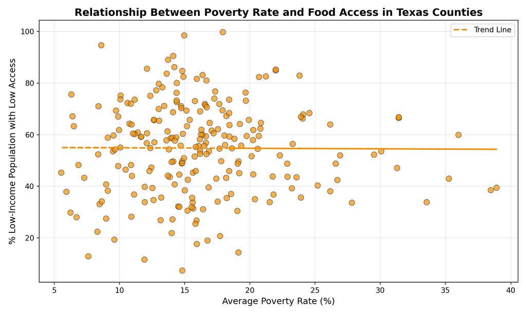

```python
# ===== Plot =====
plt.figure(figsize=(10, 6))

# Orange color scatter
plt.scatter(
    analysis_data['AvgPovertyRate'],
    analysis_data['Pct_LowIncome_LowAccess'],
    alpha=0.7,
    s=60,
    color='#F18F01',  # Nice UT-style orange
    edgecolor='black', linewidth=0.5
)

# Add orange trend line
z = np.polyfit(
    analysis_data['AvgPovertyRate'],
    analysis_data['Pct_LowIncome_LowAccess'], 1
)
p = np.poly1d(z)
plt.plot(
    analysis_data['AvgPovertyRate'],
    p(analysis_data['AvgPovertyRate']),
    color='#F18F01',
    linestyle='--',
    linewidth=2,
    label='Trend Line'
)

plt.xlabel('Average Poverty Rate (%)', fontsize=12)
plt.ylabel('% Low-Income Population with Low Access', fontsize=12)
plt.title(
    'Relationship Between Poverty Rate and Food Access in Texas Counties',
    fontsize=14,
    fontweight='bold'
)
plt.grid(alpha=0.3)
plt.legend()
plt.tight_layout()
plt.show()
```

```python
# Correlation
correlation = analysis_data['AvgPovertyRate'].corr(
    analysis_data['Pct_LowIncome_LowAccess']
)
print(f"\nCorrelation: {correlation:.3f}")
```

```
Correlation: -0.007
```

```python
print(f"Count: {len(analysis_data)}")
```

```
Count: 230
```

# 17 Challenge and How We Approached

Throughout the SQL portion of this project, we encountered multiple challenges that required careful debugging, verification, and adaptation of our data wrangling strategies. Below is a summary of the main difficulty areas and the learning outcomes associated with:

First, we frequently encountered errors such as “Referenced column not found”, which were caused by mismatched expectations of column naming. Sometimes we assumed a field existed when it did not, or we incorrectly referenced the column’s case-sensitive name. This experience taught us to always preview the dataset structure before writing queries.

A second major issue emerged from inconsistent formatting in the State column across different datasets. Some tables represented Texas as “TX” while others used “Texas,” which initially caused filtering and merging failures. We resolved this by standardizing values using CASE WHEN, learning the importance of applying transformations before joins.

Another challenge occurred during merging operations. Because the USDA dataset is at the census tract level while demographic data is county-level, incorrect joins initially caused row duplication and inaccurate aggregation. Through this, we learned to plan aggregation steps before joins and to perform row count checks after each operation to ensure data integrity.

We also discovered that missing values were represented differently across datasets. In SQL, values such as -1 were not automatically interpreted as missing. This forced us to think critically about what each placeholder meant and handle it with explicit filtering or conversion, instead of a single universal cleaning rule.

Additionally, we learned that SQL queries cannot simply be executed in one large statement without understanding the relationships between tables. We had to build pipelines step-by-step, testing smaller intermediate queries to prevent large-scale errors. This taught us to approach SQL with a structured and cautious mindset.

We also encountered uncertainty in deciding how different variables should be aggregated. Population numbers required `SUM()`, whereas rate-based metrics were better suited to `AVG()` unless weighted calculations were appropriate. This experience improved our understanding of how statistical logic must align with data type semantics.

Finally, SQL error messages were often less interpretable than those in R or Python. This forced us to develop a consistent debugging approach: simplify the query, break it into smaller parts, and validate each step using preview queries like LIMIT 5. Through repeated practice, debugging started to feel systematic.

# 18 Description of tool learning

First, We learned to use DuckDB as a fast, in-process analytical database, which allowed us to query large CSV files directly without complex server setups. After understanding the basics of SQL syntax, we explored the DuckDB documentation to learn how to efficiently load data using the read_csv_auto() function, using the nullstr=‘NULL’ parameter to correctly handle missing values that were otherwise causing type inference errors. Second, we learned to perform data transformation and cleaning directly within SQL queries. We searched online for methods to standardize inconsistent categorical data and found the CASE WHEN statement to be essential for normalizing state names (e.g., converting “TX”, “texas” to “Texas”) before performing joins. We also learned to calculate derived metrics using aggregation functions like SUM() and AVG() combined with arithmetic operators to create meaningful indicators like “Percent Low Access” directly in the database. When we encountered challenges with integer division returning zero, we searched Q&A platforms and learned to cast variables to DOUBLE to ensure precise percentage calculations. This tool was indispensable for filtering, joining, and aggregating the three disparate datasets into a single, cohesive analytical table.